# COVID-19 Mortality & Socioeconomic Trends in Michigan

### *Exploring the relationship between COVID-19 deaths and socioeconomic factors in Michigan counties*

Brooke Walters  
July 23, 2022  
Stats 518

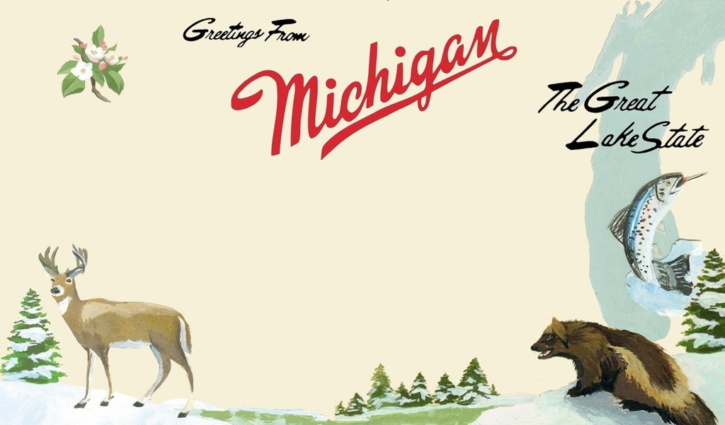

**The source code is [here](https://github.com/BrookemWalters/BrookemWalters-Portfolio/tree/main/Stats%20518%20Final%20Project/exploring%20the%20data).**  
*Note:* *This is a work in progress, and more analysis is needed to compute the statistical significance of the findings.*

## **Project Description:**

**My script automates the following:**

- **Collects** and aggregates the most recent cumulative count of COVID-19 deaths for Michigan by county
- **Calculates** COVID-19 deaths per thousand
- **Groups** the 83 counties of Michigan into 5 risk segments (quintiles), Q1 being the lowest rate of COVID-19 deaths
- **Connects** to the census.gov database and retrieves the latest population estimates
- **Compiles** the unemployment rate, education rate, household public assistance utilization rate, median income, median age, and county racial compositions
- **Joins** the two datasets together via county
- **Reveals** the summary statistics of the numeric variables
- **Vizualizes** the data into [tables](https://github.com/BrookemWalters/BrookemWalters-Portfolio/edit/main/Stats%20518%20Final%20Project/Summary%20of%20Findings.md#the-tables-explained) and [scatter plots](https://github.com/BrookemWalters/BrookemWalters-Portfolio/blob/main/Stats%20518%20Final%20Project/Summary%20of%20Findings.md#scatter-plots)

*As of July 30th 2022, this data reflects COVID-19 deaths as of July 28th 2022*

**[Sources](https://github.com/BrookemWalters/BrookemWalters-Portfolio/blob/main/Stats%20518%20Final%20Project/Sources/sources.md#sources)**: *American Community Survey [(ACS)](https://www.census.gov/programs-surveys/acs/about.html) 2016 - 2020 Estimates, and the COVID-19 Data [Repository](https://github.com/CSSEGISandData/COVID-19) by the Center for Systems Science and Engineering (CSSE) at Johns Hopkins University*

## How To Use

**There are {five} sites to visit:** *follow the **{Click ME}** link or image to explore the data*

#### Table of County Demographics and COVID-19 Mortality [{Click ME}](https://073308-brooke.shinyapps.io/MIShiny/)

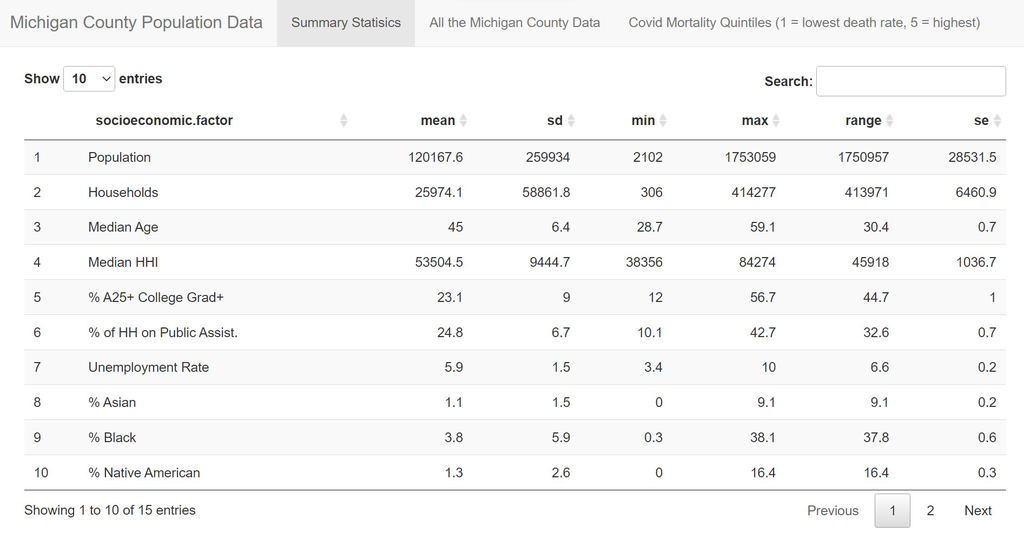

#### The Tables Explained:

**Here are a few traits of the average Q1 county:** - medium sized populations - younger residents - highly educated residents - the highest median income of all the quintiles - racially diverse - the least amount of unemployment - the least amount of households on public assistance

**Example Q1 counties include:** - Kent - Alger - Grand Traverse - Kalamazoo - Marquette

## The Scatter Plots

The interactive graphs show the relationship between one socioeconomic variable and the COVID-19 mortality rate. After clicking on the link, hover over a plot to learn more about the county. The larger the bubble, the more deaths that county experienced. The higher the quintile, the more death the county experienced per 1000.

#### “COVID-19 Mortality (quintiles) by Median Age in Michigan Counties” [{Click ME}](https://rpubs.com/ekoorb03/plots_medianage)

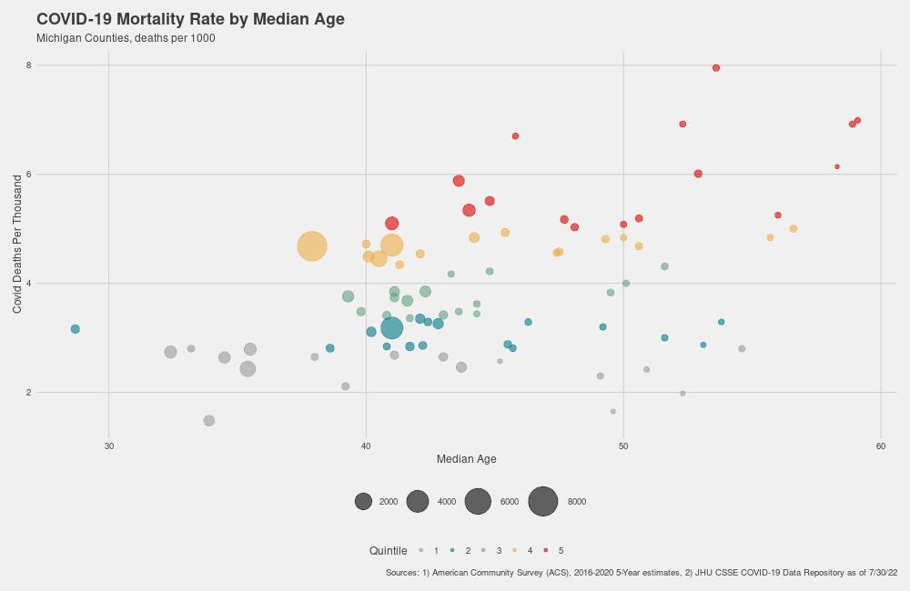

> *moderate positive relationship between median age and COVID-19 mortality rate: r = 0.49* *as rates of median age increases, the COVID-19 mortality rate increases*

> The figure shows that Otononagon, a Q5 county, has the highest median age of 59.1. *As of August 1st 2022, 40 people died of COVID-19 (7.0 per thousand) in Otononagon county*

#### “COVID-19 Mortality (quintiles) by % of Households on Public Assistance in Michigan Counties”[{Click ME}](https://rpubs.com/ekoorb03/plots_pubassistance)

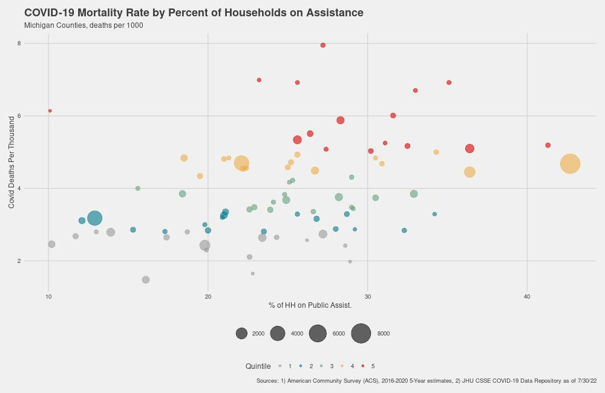

> *weak positive relationship between the percentage of households on public assistance and COVID-19 mortality rate: r = 0.37* *as rates of public assistance increase, the COVID-19 mortality rate increases*

> Wayne, the most populous and a Q4 county, stands out as the area with the highest percentage of households on public assistance.  
> *As of August 1st 2022, 8190 people died of COVID-19 (4.7 per thousand) in Wayne county.*

#### “COVID-19 Mortality (quintiles) by Median income in Michigan Counties” [{Click ME}](https://rpubs.com/ekoorb03/plots_income)

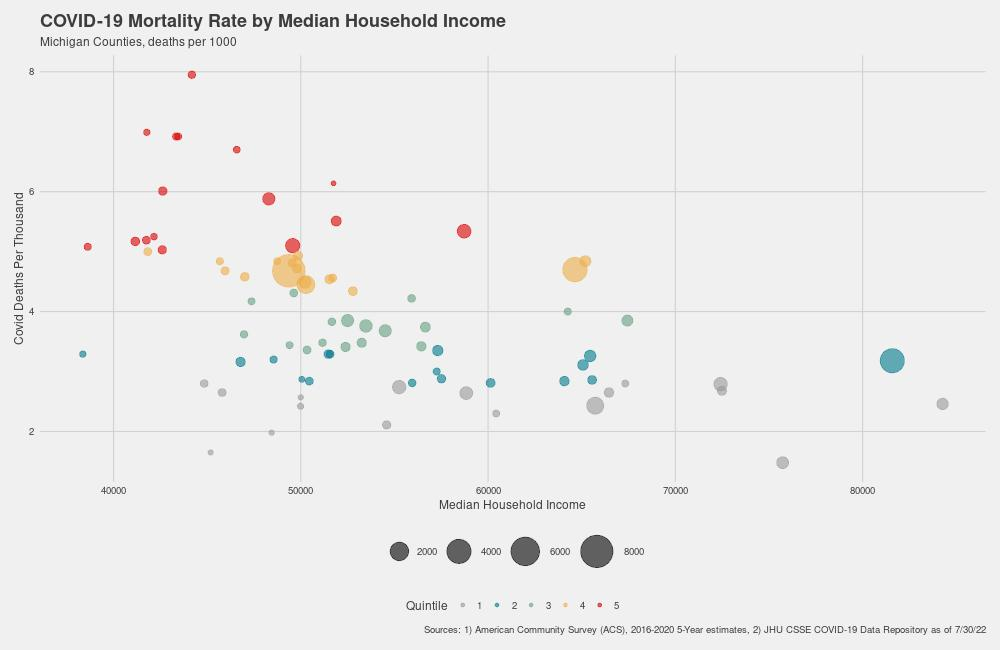

> *moderate negative relationship between the median income and COVID-19 mortality rate: r = -0.50* *as incomes increases the COVID-19 mortality rate lessens*

#### “COVID-19 Mortality (quintiles) by % of Adults 25+ with 4 year degrees or higher in Michigan Counties” [{Click ME}](https://rpubs.com/ekoorb03/plots_education)

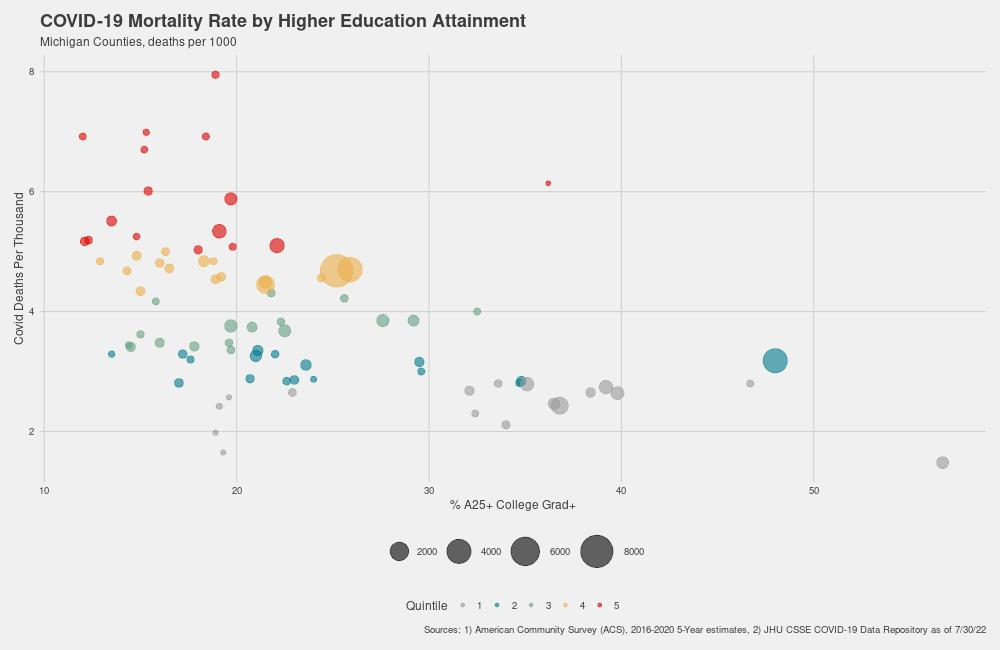

> *moderate negative relationship between the percentage of adults 25+ with college degrees and COVID-19 mortality rate: r = -0.50* *as percentage of education attainment increases the COVID-19 mortality rate lessens*

> Home to the University of Michigan, Washtenaw is Michigan’s most educated county, with 56.7% This Q1 county stands out considering most Michgian counties fall under 30 %

> *As of August 1st 2022, 545 people died of COVID-19 (1.5 per thousand) in Washtenaw county.*

**Back to the [bias disclosure and intro](https://github.com/BrookemWalters/BrookemWalters-Portfolio/edit/main/Stats%20518%20Final%20Project/Introduction.md).**  
**Jump to the [source code](https://github.com/BrookemWalters/BrookemWalters-Portfolio/tree/main/Stats%20518%20Final%20Project/exploring%20the%20data).**

###### —[Back to Table of Contents](https://github.com/BrookemWalters/BrookemWalters-Portfolio#table-of-contents-brooke-walters-portfolio)—